# Introduction to Causal Modeling: Potential Outcomes

Oisin Ryan

# Data and R-packages

Throughout this practical you will make use of various R-packages. All packages necessary can be installed by running `setup.R`. If you haven’t done this already, install the following packages:

```r
# install.packages("tableone")
# install.packages("MatchIt")
# install.packages("survey")
```

In this practical we will get some practice using tools from the potential outcomes framework. To do this we will use data from Schafer and Kang (2008). We will reproduce only a small part of their analyses, but you can read up on even more ways to estimate causal effects from nonrandomized studies in their paper.

Schafer, J. L., and Kang, J. (2008). Average causal effects from nonrandomized studies: A prectical guide and simulated example. *Psychological methods, 13*, 279-313. DOI: 10.1037/a0014268

The data are found in the datafile called `SchaferKangData.dat`. The dataset represents a (simulated) two-wave observational study on emotional distress and dieting behaviour in adolescent girls. Our research question is: What is the effect of dieting on emotional distress? We will apply several different methods we learned about in the lecture to answer this question. For null hypothesis tests, you can use a significance level of 0.05 throughout.

# Exercise 1

Load the data. The outcome variable is `DISTR.2` a continuous variable measuring emotional distress at the second measurement wave. The *treatment* variable is `DIET`, a binary variable indicating the presence or absence of dieting behaviour at wave I. All other variables should be considered measurements of covariates at wave 1.

```r
df <- read.table("SchaferKangData.dat", header=T)
head(df)
```

```
##   DISTR.1 BLACK NBHISP GRADE SLFHLTH SLFWGHT WORKHARD GOODQUAL PHYSFIT PROUD
## 1    0.47     0      0    10       4       4        2        2       2     2
## 2    0.05     0      0     8       2       3        1        1       2     1
## 3    0.63     0      0     8       2       3        2        2       2     2
## 4    0.16     1      0     9       1       4        2        1       2     1
## 5    1.79     1      0     9       4       4        1        2       2     2
## 6    0.32     0      0    10       1       3        1        1       2     1
##   LIKESLF ACCEPTED FEELLOVD DIET DISTR.2
## 1       5        2        2    1    0.40
## 2       1        2        1    1    0.09
## 3       3        2        2    0    0.69
## 4       2        2        1    1    0.08
## 5       3        3        2    0    1.41
## 6       4        1        1    0    0.52
```

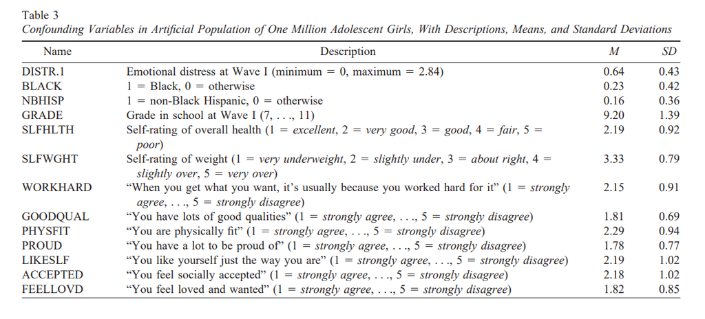

## No covariates included

When a randomized controlled trial (RCT) has been conducted, the treatment groups should not differ on any (pre-treatment) covariates due to random assignment. In that case, the ACE can be computed by taking the difference in means between the two groups for the outcome variable. This is also referred to as the prima facie effect.

$\blacktriangleright$ Compare the means between the groups on the outcome variable (use for instance `t.test()` in R). What do you conclude?

```r
t.test1 <- t.test(DISTR.2 ~ DIET, df)
# Difference in means between the groups:
m1 <- t.test1$estimate[2]
m0 <- t.test1$estimate[1]

m1 - m0
```

```
## mean in group 1
##      0.05961424
```

```r
# p-value
t.test1$p.value
```

```
## [1] 0.0001054363
```

The mean difference here is the naive estimate of the average causal effect of dieting on distress. The results indicate that the average of the girls who did diet is (0.703-0.645=)0.059 points higher than the average of the girls who did not diet ($SE=0.015$). This difference is statistically significant.

The mean difference above is a valid estimate of the causal effect only under the assumption that there is no confounding. We have a set of observed covariates, and if our data do in fact mimic an RCT, there should be no mean differences between the two groups on these covariates.

You can check this by plotting this histograms of the observed variables across dieting groups, for example:

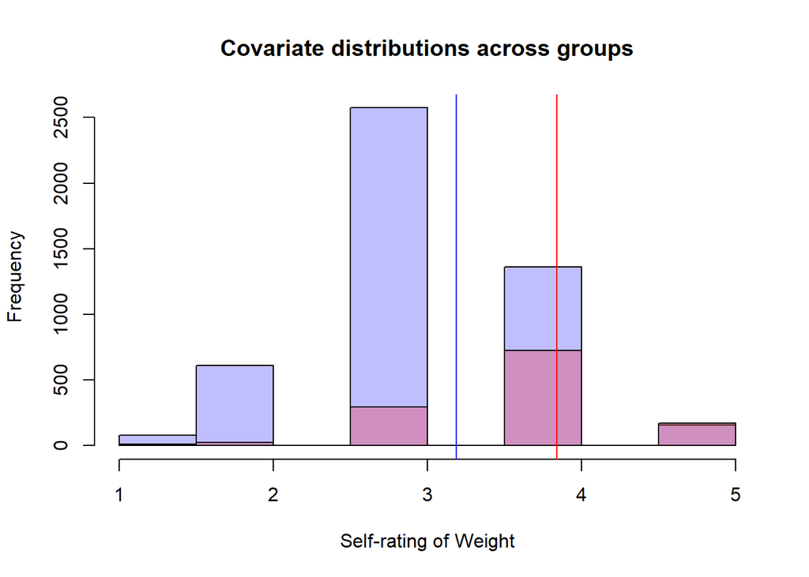

```r
p1 <- hist(df[,"SLFWGHT"][df$DIET == 0], plot = F)
p2 <- hist(df[,"SLFWGHT"][df$DIET == 1], plot = F)
plot( p1, col=rgb(0,0,1,1/4), xlim=c(1,5), main = "Covariate distributions across groups",
      xlab = "Self-rating of Weight")  # first histogram
plot( p2, col=rgb(1,0,0,1/4), xlim=c(1,5), add=T)  # second
abline(v = mean(df[,"SLFWGHT"][df$DIET == 0]), col = "blue")
abline(v = mean(df[,"SLFWGHT"][df$DIET == 1]), col = "red")
```

Alternatively, you can use the function `CreateTableOne()` from the package `tableone` to check this. This gives us a comparison between dieting groups across all covariates. The `SMD` column represents the standardized mean difference. A general rule of thumb is that a `SMD` bigger than .1 indicates some degree of imbalance between the covariate distributions.

```r
library(tableone)
table1 <- CreateTableOne(vars=c("DISTR.1","BLACK", "NBHISP", "GRADE",
                      "SLFHLTH", "SLFWGHT", "WORKHARD", "GOODQUAL",
                          "PHYSFIT", "PROUD", "LIKESLF", "ACCEPTED",
                      "FEELLOVD"), strata="DIET", data=df,
                        test=FALSE)
print(table1, smd=TRUE)
```

```
##                       Stratified by DIET
##                        0           1           SMD
##   n                    4780        1220
##   DISTR.1 (mean (SD))  0.62 (0.42) 0.71 (0.45)  0.214
##   BLACK (mean (SD))    0.26 (0.44) 0.17 (0.38)  0.197
##   NBHISP (mean (SD))   0.15 (0.35) 0.15 (0.36)  0.021
##   GRADE (mean (SD))    9.16 (1.39) 9.37 (1.34)  0.152
##   SLFHLTH (mean (SD))  2.20 (0.93) 2.35 (0.91)  0.171
##   SLFWGHT (mean (SD))  3.19 (0.76) 3.84 (0.70)  0.895
##   WORKHARD (mean (SD)) 2.14 (0.91) 2.05 (0.85)  0.093
##   GOODQUAL (mean (SD)) 1.80 (0.67) 1.84 (0.71)  0.055
##   PHYSFIT (mean (SD))  2.24 (0.93) 2.53 (0.93)  0.320
##   PROUD (mean (SD))    1.76 (0.77) 1.86 (0.79)  0.126
##   LIKESLF (mean (SD))  2.09 (0.99) 2.52 (1.06)  0.420
##   ACCEPTED (mean (SD)) 2.14 (1.00) 2.35 (1.06)  0.207
##   FEELLOVD (mean (SD)) 1.78 (0.83) 1.93 (0.90)  0.172
```

Let’s take this result as an indication that the covariate distributions may be unbalanced across treatment groups.

# Exercise 2: Propensity Scores

There are many options available to us if we want to condition on our set of covariates. For example, we could perform a regression or ANCOVA and include all of the variables above as linear predictors. But there are some problems with this approach: these approaches can be quite unstable, when we consider diverse combinations of predictors, they rely on assumptions of linearity of the covariate effects, and may rely on linear extrapolation if we do not observe all covariate values across both dieting and non-dieting groups.

A different approach to handle observed confounding is by computing propensity scores: These represent the probability of treatment for each case based on the covariates. This propensity score can then be used in diverse techniques to mimic a randomized controlled trial. Here we show you two of these approaches

- matching, in which we try to create pairs of a treated and an untreated individual that have the same propensity score
- inverse probability weighting, in which we create a pseudo-population that is balanced on the covariates

$\blacktriangleright$ To compute a propensity score, run a logistic regression model in which the binary treatment variable X (values 0 and 1) is the outcome variable, and the covariates are the predictors. Make sure to save the probability for each person of scoring 1 on X. You can use the `glm` function from the `stats` package for this.

```r
# Run the logistic regression analysis
logreg <- glm(DIET ~ DISTR.1 + as.factor(BLACK) + as.factor(NBHISP)
    + GRADE + SLFHLTH + SLFWGHT + WORKHARD + GOODQUAL
        + PHYSFIT + PROUD + LIKESLF + ACCEPTED + FEELLOVD,
            family = binomial(), data = df)
# Obtain a prediction of the probability of treatment (i.e., DIET=1)
ps <- predict(logreg, type = "response")
# Add this predicted probability to the datafile
df$ps <- ps
```

Now that we have the propensity scores, we should first consider the distribution of propensity scores in each of the treatment groups separately, to determine whether there is overlap between the propensity scores of the two groups.

$\blacktriangleright$ Make a histogram to look at this, discuss what you see, and why this is important.

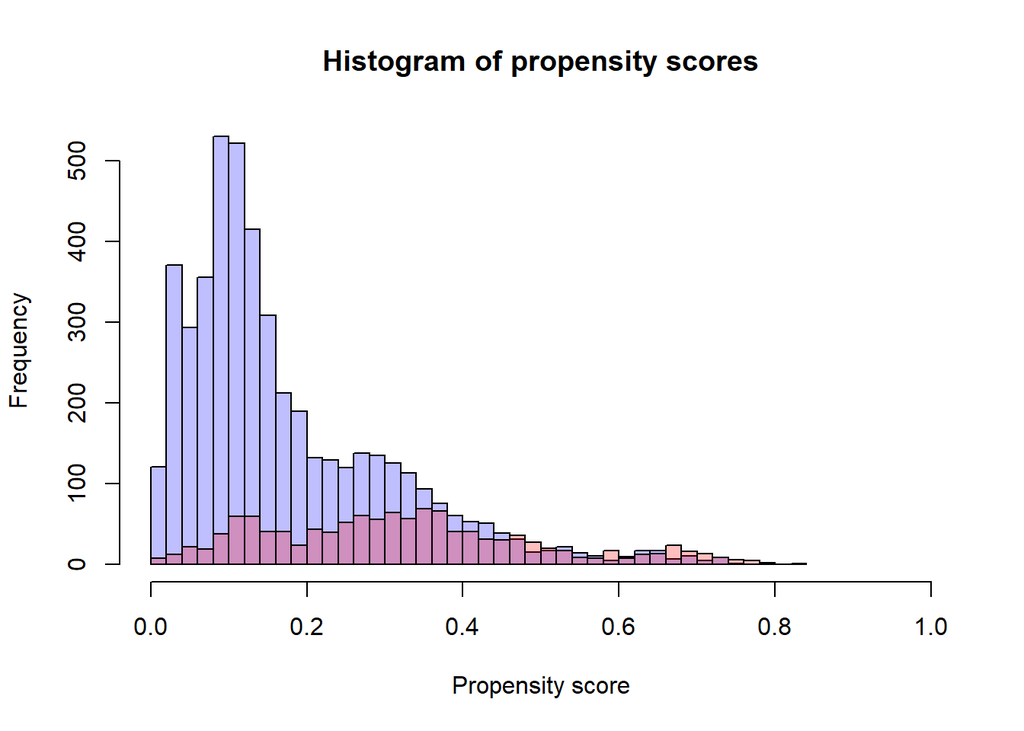

```r
df1 <- df[ which(df$DIET == 1), ]
df0 <- df[ which(df$DIET == 0), ]
hist0 <- hist(df0$ps, breaks=30, plot=FALSE)
hist1 <- hist(df1$ps, breaks=30, plot=FALSE)
plot( hist0, col=rgb(0,0,1,1/4), xlim=c(0,1),
    xlab="Propensity score", main="Histogram of propensity scores")
plot( hist1, col=rgb(1,0,0,1/4), xlim=c(0,1), add=T)
```

What we see is that the two groups seem to overlap well, even in the tails. If this would not be the case, that would be an indication that the assumption of positivity is violated. That is, at each possible combination of the covariates, which is now summarized with the propensity score, there should be both treated and non-treated individuals in our sample.

## Method 1: *Matching*

Matching is based on finding people in the two treatment groups that have similar propensity scores. This is done by taking a person from the smallest of the two groups (here the group for which DIET=1), and finding a person in the other group that is most like this person in terms of its propensity score. We can do this using the function `matchit()` from the package `MatchIt` in R.

$\blacktriangleright$ Run the matching function, using the method “nearest”, and call the output “matchdat”, as shown below, and interpret the results that you see.

```r
library(MatchIt)
matchdat <- matchit(DIET ~ DISTR.1 + as.factor(BLACK) + as.factor(NBHISP)
            + GRADE + SLFHLTH + SLFWGHT + WORKHARD + GOODQUAL
            + PHYSFIT + PROUD + LIKESLF + ACCEPTED + FEELLOVD,
        method = "nearest",  data = df)
matchdat
```

```
## A matchit object
##  - method: Variable ratio 1:1 nearest neighbor matching without replacement
##  - distance: Propensity score
##              - estimated with logistic regression
##  - number of obs.: 6000 (original), 2440 (matched)
##  - target estimand: ATT
##  - covariates: DISTR.1, as.factor(BLACK), as.factor(NBHISP), GRADE, SLFHLTH, SLFWGHT, WORKHARD, GOODQUAL, PHYSFIT, PROUD, LIKESLF, ACCEPTED, FEELLOVD
```

The results indicate that the original sample consisted of 6000 individuals, and that the matched sample consists of 2440 individuals. This is because the number of treated individuals is 1220, and these were all matched with a non-treated person. Note that we could extend the expression above to include non-linear relations (by squaring covariates), and by including interaction term between two covariates. This will lead to different propensity scores, which may subsequently lead to different matches.

$\blacktriangleright$ There are two useful plotting options regarding the propensity scores of our matched pairs: `plot(matchdat,type="jitter")` and `plot(matchdat,type="hist")`. Below we plot the former.

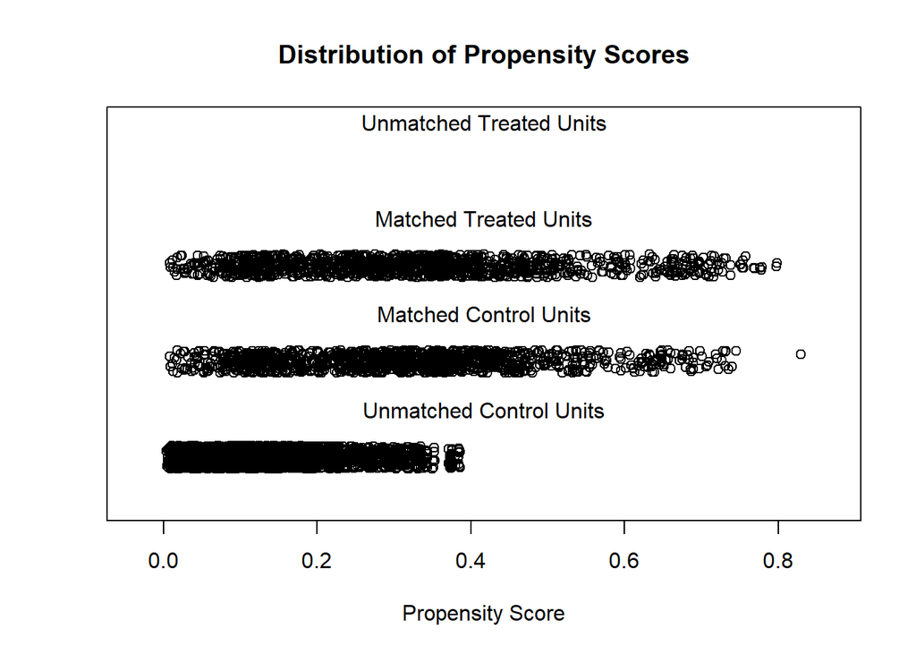

```
## [1] "To identify the units, use first mouse button; to stop, use second."
```

```
## integer(0)
```

```r
plot(matchdat,type="jitter")
```

This is a plot of the propensity scores of four different subgroups. Those from the treatment group for whom there was no match. Those from the treatment group for whom there was a match. Those from the control group for whom there was a match. Those from the control group for whom there was no match. It shows the first group is empty; it shows the last group has relatively low propensity scores; the middle two groups seem pretty similar in terms of their propensity score distribution (as expected, as these are the matched cases).

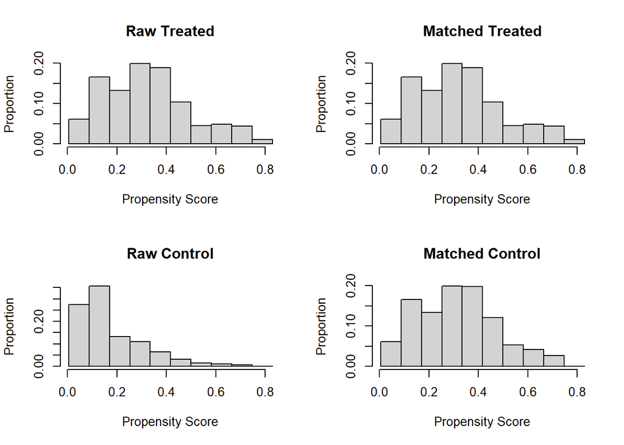

```r
plot(matchdat,type="hist")
```

This plot shows the histograms of the propensity scores of the two treatment groups in the original dataset on the left and for the matched groups on the right; it shows that the latter are far more similar than the former (as one would expect).

$\blacktriangleright$ Now create the new datafile with only the matched cases, using: `df.match <- match.data(matchdat)`

```r
# To extract the new datafile from the original one;
df.match <- match.data(matchdat)
```

$\blacktriangleright$ For this new dataset, make the Table 1 again (with the standardized mean differences $\Delta Z$ for all the covariates). What can you conclude?

```r
table1 <- CreateTableOne(vars=c("DISTR.1","BLACK", "NBHISP", "GRADE",
                      "SLFHLTH", "SLFWGHT", "WORKHARD", "GOODQUAL",
                          "PHYSFIT", "PROUD", "LIKESLF", "ACCEPTED",
                      "FEELLOVD"), strata="DIET", data=df.match,
                        test=FALSE)
print(table1, smd=TRUE)
```

```
##                       Stratified by DIET
##                        0           1           SMD
##   n                    1220        1220
##   DISTR.1 (mean (SD))  0.71 (0.45) 0.71 (0.45)  0.007
##   BLACK (mean (SD))    0.18 (0.38) 0.17 (0.38)  0.004
##   NBHISP (mean (SD))   0.16 (0.36) 0.15 (0.36)  0.007
##   GRADE (mean (SD))    9.37 (1.35) 9.37 (1.34)  0.002
##   SLFHLTH (mean (SD))  2.36 (0.95) 2.35 (0.91)  0.011
##   SLFWGHT (mean (SD))  3.82 (0.69) 3.84 (0.70)  0.033
##   WORKHARD (mean (SD)) 2.07 (0.86) 2.05 (0.85)  0.022
##   GOODQUAL (mean (SD)) 1.81 (0.65) 1.84 (0.71)  0.049
##   PHYSFIT (mean (SD))  2.53 (0.97) 2.53 (0.93)  0.007
##   PROUD (mean (SD))    1.85 (0.77) 1.86 (0.79)  0.011
##   LIKESLF (mean (SD))  2.46 (1.05) 2.52 (1.06)  0.057
##   ACCEPTED (mean (SD)) 2.33 (1.03) 2.35 (1.06)  0.023
##   FEELLOVD (mean (SD)) 1.92 (0.87) 1.93 (0.90)  0.010
```

This shows that the standardized mean differences are all quite small in this matched dataset; this means the two groups are now very similar on the covariates, just as one would expect in an RCT. Hence, matching seems to mimic an RCT here (at least with respect to observed covariates; note there may still be unobserved confounding).

$\blacktriangleright$ Investigate with a t-test whether the means on the outcome variable DISTR.2 differ *among the matched cases*. Compare this result to the mean comparison you did at the start; explain why the mean differences that you have just determined is an estimate of the ACE1 rather than of the ACE.

```r
t.test2 <- t.test(DISTR.2 ~ DIET, df.match)
t.test2$estimate
```

```
## mean in group 0 mean in group 1
##       0.7253279       0.7031393
```

```r
t.test2$stderr
```

```
## [1] 0.01949278
```

Initially, the difference was 0.0596, meaning that those who diet experience more distress than those who do not diet. Here the difference between the matched cases is 0.703-0.725=-0.022 (SE=0.019) which implies that among those girls who are likely to diet, dieting (the treatment condition: DIET=1) seems to result in less distress than not dieting (the no treatment condition: DIET=0). Note the “girls who are likely to diet” comment: This is referring to the fact that we have taken the sample that did diet, and then found matches for these participants who did not diet. However, given the relatively large SE, this is not a significant difference.

## Method 2: *Inverse Probability Weighting*

We can also use inverse probability weighting (IPW) to account for unbalanced covariates. In this case, the estimated propensity scores $\hat{\pi}_i$ are used to determine the probability that an individual would have received the treatment that they received:

- for the treated ($X_i=1$) this is simply $\hat{\pi}_i$
- for the non-treated ($X_i=0$) this is $1-\hat{\pi}_i$.

Next, we can use these probabilities as weights, by taking their inverse: That way, a case that received a treatment that she was very likely to receive, will get a small weight, while a case that received a treatment that she was very unlikely to receive, will get a large weight. Thus, the inverse probability weight indicates the number of persons from the population that this person represents. For the treated, this weight is $1/\hat{\pi}_i$; for the untreated, it is $1/(1-\hat{\pi}_i)$.

We can compute our estimate of the IPW-weighted ACE following the formulas given in the slides, or by using techniques which allow us to include weights directly. One such approach is available in the `survey` package. First, we create the weighted datafile (i.e., the pseudo population), and check the `SMDs` again.

```r
library(survey)
library(tableone)
weight <- ifelse(df$DIET==1,1/(df$ps),1/(1-df$ps))
weighteddata <- svydesign(ids = ~ 1,
                          data = df,
                          weights = ~ weight)
weightedtable <- svyCreateTableOne(
                        vars=c("DISTR.1","BLACK", "NBHISP", "GRADE",
                               "SLFHLTH", "SLFWGHT", "WORKHARD", "GOODQUAL",
                                   "PHYSFIT", "PROUD", "LIKESLF", "ACCEPTED",
                               "FEELLOVD"),
                        strata = "DIET", data = weighteddata, test = FALSE)
print(weightedtable, smd = TRUE)
```

```
##                       Stratified by DIET
##                        0              1              SMD
##   n                    6014.23        6368.45
##   DISTR.1 (mean (SD))     0.64 (0.43)    0.63 (0.43)  0.028
##   BLACK (mean (SD))       0.24 (0.43)    0.25 (0.44)  0.035
##   NBHISP (mean (SD))      0.15 (0.35)    0.13 (0.33)  0.061
##   GRADE (mean (SD))       9.20 (1.38)    9.26 (1.41)  0.037
##   SLFHLTH (mean (SD))     2.23 (0.94)    2.25 (0.91)  0.020
##   SLFWGHT (mean (SD))     3.33 (0.80)    3.15 (1.00)  0.196
##   WORKHARD (mean (SD))    2.12 (0.90)    2.14 (0.86)  0.017
##   GOODQUAL (mean (SD))    1.81 (0.67)    1.79 (0.68)  0.036
##   PHYSFIT (mean (SD))     2.30 (0.95)    2.31 (0.90)  0.014
##   PROUD (mean (SD))       1.78 (0.77)    1.77 (0.76)  0.018
##   LIKESLF (mean (SD))     2.18 (1.02)    2.14 (1.00)  0.045
##   ACCEPTED (mean (SD))    2.18 (1.01)    2.16 (1.02)  0.024
##   FEELLOVD (mean (SD))    1.81 (0.84)    1.79 (0.83)  0.028
```

This shows that in the pseudo-population that was created using IPW, the two groups do not differ much any more on most of the covariates; however, there is one covariate `SLFWGHT`, whose standardized mean difference exceeds the rule of thumb value of 0.1. This implies that IPW is not entirely successful here in mimicing an RCT. We nevertheless proceed, but it would be better to check whether there are for instance very large weights, such that there are cases that have a disproportional effect on the results, and to fix this first (for instance by deleting these cases, or replacing their weight by a large yet not excessive value). Hopefully, that would fix the problem with the standardized mean differences. For now we proceed, using a function from the package survey.

```r
msm <- svyglm(DISTR.2 ~ DIET, design = weighteddata)
summary(msm)
```

```
##
## Call:
## svyglm(formula = DISTR.2 ~ DIET, design = weighteddata)
##
## Survey design:
## svydesign(ids = ~1, data = df, weights = ~weight)
##
## Coefficients:
##              Estimate Std. Error t value Pr(>|t|)
## (Intercept)  0.660949   0.007029  94.032   <2e-16 ***
## DIET        -0.005064   0.030394  -0.167    0.868
## ---
## Signif. codes:  0 '***' 0.001 '**' 0.01 '*' 0.05 '.' 0.1 ' ' 1
##
## (Dispersion parameter for gaussian family taken to be 0.2397251)
##
## Number of Fisher Scoring iterations: 2
```

```r
confint(msm)
```

```
##                   2.5 %     97.5 %
## (Intercept)  0.64716947 0.67472808
## DIET        -0.06464777 0.05451944
```

This shows that the effect of dieting is now estimated to be -0.005 (SE=0.030), which is not significantly different from zero.

# Conclusion

The two methods that we considered in this category are all based on using the propensity score, that is, the probability of being treated given the covariates. The goal of these techniques is to somehow mimic the situation we get in an RCT, where the probability of treatment is independent of the covariates. In matching, this is done by creating pairs of a treated and an untreated person who have (almost) identical propensity scores, resulting in a smaller but balanced dataset; in inverse probability weighting, this is done by weighing each person’s observation by their inverse probability of received treatment, thereby creating a balanced peudo-population. In each approach, we should check whether it balances the covariates, for instance, by considering the standardized mean differences (for other options, see for instance: Austin, P. c. (2009). Balance diagnostics for comparing the distribution of baseline covariates between treatment groups in propensity-score matched samples. *Statistics in Medicine, 28*, 3093-3107. https://doi.org/10.1002/sim.3697). Many other options exist for using propensity scores to mimic RCTs, with many of these surveyed and compared in Schafer & Kang (2008).

It is important to always keep in mind that all the techniques discussed here were developed under the assumption of no unobserved confounding. This means that all relevant confounders should be included as covariates. Sensitivity analysis is a valuable approach to investigate how the effect of unobserved confounding can be further investigated (not covered in this course; for more information see for instance: Blackwell, M. (2013). A selection bias approach to sensitivity analysis for causal effects. *Political Analysis, 22*, 169-182. https://doi.org/10.1093/pan/mpt006).